# ICA 1

Student number: 20017151

## 1. The cooked books

Let $Y$ be the numbers of arrivals to boutique shop each day, and $Y \sim \text{Poi}(\lambda)$, $\lambda$>0. We have that:

$$E[Y] = \sum_{y=0}^{\infty} y
\mathbb{P}(Y=y) = \sum_{y=1}^{\infty} y \frac{\lambda^y
e^{-\lambda}}{y!}$$
Let $X$ be the numbers of arrivals to boutique shop each day, using “cooked” numbers. When $X=0$, $Y=0$ or $Y=1$, hence we know that:
$$E[X] = 1 \times(\mathbb{P}(Y=0) +
\mathbb{P}(Y=1)) + \sum_{y=2}^{\infty} y \mathbb{P}(Y=y) = e^{-\lambda}
+ E[Y]$$

$$E[X] = E[Y] + \mathbb{P}(Y=0) = E[Y] +
e^{-\lambda} = {\lambda} + e^{-\lambda}$$
If we let $X_1, \ldots, X_{n}$ be the arrivals each day, with cooked data, and independent of each other. Using law of large numbers, we know that as $n {\to} \infty$:

$$\frac{1}{n} (X_1+\ldots+X_n) \quad {\to}
\quad E[X_1] = {\lambda} + e^{-\lambda}$$
We can derive an estimate of $\lambda$ by first determining the sample mean of the cooked datasets and then use numerical methods to solve for $\lambda$. This approach takes into account the modified zero counts, offering an unbiased estimator of the true parameter $\lambda$. However, as we are estimating the parameter using numerical methods, some bias might be generated.

```r
set.seed(1) # To create reproducible results

# Define parameters
lambda <- 1 # lambda = 1
N <- 100 # Number of samples
sample_size <- 300

# Function which finds the estimated lambda based on the sample mean
solution_lambda <- function(mean_sample, min, max) {

  eq <- function(lambda) {
    lambda + 1/exp(lambda) - mean_sample # Want to find the root of this expression
  }

  solution <- uniroot(eq, c(min, max))
  return(solution$root)
}

estimated_lambda <- c() # Want to store estimated lambda values

for (sim in 1:N) {
  data <- rpois(sample_size, lambda) # Generate and cook data
  data[data == 0] <- 1

  mean_sample <- mean(data)
  i <- solution_lambda(mean_sample, 0, 2) # Estimate lambda using sample mean of cooked data
  estimated_lambda <- c(estimated_lambda, i)
}

mean_estimated_lambda <- mean(estimated_lambda) # Mean of the estimated lambdas
print(mean_estimated_lambda)
```

```
## [1] 0.9960598
```

```r
print(1-mean_estimated_lambda) # Compare the true parameter with the mean of the estimated lambdas
```

```
## [1] 0.003940236
```

We can see that the estimate is very close to the true parameter which is 1.

```r
# Read the data from the provided file and store it in provided_data
provided_data <- c(2, 1, 2, 1, 1, 4, 1, 4, 2, 4, 1, 2, 3, 1, 1, 3, 1, 5, 1, 2, 4, 2, 1, 3, 2, 1, 1, 2, 1, 2, 2, 1, 4, 2, 1, 2, 2, 1, 1, 1, 2, 2, 5, 4, 3, 4, 1, 2, 3, 1, 2, 2, 3, 2, 2, 1, 1, 2, 3, 2, 1, 1, 2, 1, 2, 1, 2, 1, 1, 2, 1, 1, 3, 1, 2, 4, 2, 3, 4, 7, 1, 2, 2, 1, 2, 1, 3, 2, 5, 4, 1, 1, 2, 2, 1, 5, 3, 2, 3, 1, 1, 4, 1, 1, 7, 6, 3, 2, 1, 6, 3, 4, 3, 1, 1, 2, 2, 1, 4, 1, 2, 3, 2, 2, 2, 1, 1, 4, 4, 6, 3, 1, 1, 2, 1, 4, 2, 4, 3, 1, 5, 2, 1, 2, 3, 3, 4, 2, 1, 4, 3, 2, 2, 1, 3, 2, 3, 3, 1, 2, 4, 3, 4, 1, 3, 5, 1, 2, 1, 1, 1, 1, 3, 1, 4, 4, 1, 2, 4, 2, 5, 1, 1, 2, 2, 3, 4, 2, 2, 4, 1, 2, 2, 4, 1, 5, 2, 3, 1, 2, 2, 2, 2, 4, 1, 1, 4, 1, 4, 5, 1, 3, 1, 3, 2, 1, 2, 5, 1, 2, 1, 2, 6, 1, 1, 1, 1, 4, 4, 2, 1, 1, 2, 2, 3, 3, 4, 4, 1, 2, 5, 1, 1, 1, 2, 4, 1, 1, 2, 1, 1, 1, 2, 1, 3, 1, 4, 4, 1, 2, 4, 1, 3, 1, 3, 2, 6, 2, 2, 3, 1, 4, 3, 1, 7, 1, 4, 2, 5, 3, 4, 2, 6, 6, 3, 4, 1, 1, 3, 2, 3, 1, 1, 2, 3, 3, 2, 1, 1, 2)

provided_sample_mean <- mean(provided_data) # Calculate the mean

# Using the same method as above
estimated_lamdbda_provided <- solution_lambda(provided_sample_mean, 0, 8)
estimated_lamdbda_provided
```

```
## [1] 2.229025
```

The estimated $\lambda$ for the given sample is 2.229025.

## 2. The half parabola

Region $R$ is bounded by the $x$-axis and the function $f(x) = \tfrac{3}{2}(1 -x^2)$, for $x \in [0,1]$.

- Want to sample a point $U$, uniformly at random on $R$. By the acceptance/rejection method, we sample from $(W,X) =(w,x)$, where $W \sim \text{U}(0,1)$, $X \sim \text{U}(0,1)$, and $W \perp\!\!\!\perp X$. If the inequality $w\times M \leq \frac{f(x)}{g(x)}$ holds, where $g(x) = 1$ on $[0,1]$ and $M = \frac{3}{2}$, we accept the x-value such that $U = x$, if not, we reject the point.

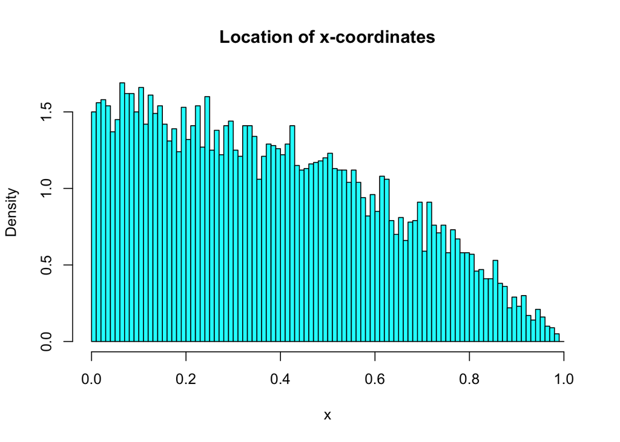

```r
# Define function to do the sampling of U
sampling_fromR <- function() {
u = -1
while(u == -1){
  # Sample from W and X
  w = runif(1)
  x = runif(1)

  # Check if the sampled point satisfies the acceptance/rejection criterion
  if(w*1.5 < (3/2)*(1-x^2)) {
    u <- x # If the criterion is met, accept x
    }
  }
  return(u)
}

# Plot the histogram of x-coordinates
sampled_points <- replicate(10000, sampling_fromR())
hist(sampled_points, prob=TRUE, seq(0, 1, by=0.01),  col = "cyan", main = "Location of x-coordinates", xlab = "x")
```

- The pdf of $X$, where $X$ is the x-coordinate of $U$, is: $h(x) = {\frac{3}{2}(1 - x^2)}$ on $[0,1]$ and $0$ otherwise.

- No, $X$ and $Y$ are not independent since the range of $Y$ depends on the chosen value of $X$, i.e. for a chosen $X$, $Y$ is constrained by the value of $X$.

## 3. The Casino

First define the notation: Let 1 denote that the gambler plays blackjack, and let 2 denote that the gambler plays roulette.

The transition matrix is as follows:
$$P = \begin{pmatrix}
P_{1,1} & P_{1,2} \\
P_{2,1} & P_{2,2} \\
\end{pmatrix} =
\begin{pmatrix}
0.43 & 0.57 \\
36/37 & 1/37 \\
\end{pmatrix}$$
Simulate the Markov chain for $N=100000$ bets/steps:

```r
# Define the transition matrix for the Markov chain
P <- matrix(c(0.43, 0.57, 36/37, 1/37), nrow = 2)
P <- t(P)
P
```

```
##          [,1]       [,2]
## [1,] 0.430000 0.57000000
## [2,] 0.972973 0.02702703
```

Using method from lectures to construct Markov chains

```r
set.seed(123) # To create reproducible results

# Define function which simulates a single step in the Markov chain
step <- function(i) {
  q = P[i,] # Probabilities of moving from current state i to other states
  cumq = cumsum(q) # Cumulative sum of probabilities
  u = runif(1)  # Generate a uniform random number

  j = 0
  x = -1
  while(x == -1){
    j <- j + 1
    if (u <= cumq[j]) { # The next state is determined based on u
      x <- j
      }
  }
  return(x)
}

# Define function which simulates N steps in the Markov chain, using the function above
steps <- function(N){
  x = 1
  for (i in 1:N){
    x <- c(x, step(x[i]))
  }
  return(x)
}

# Simulate the chain for 100 000 steps
N <- 100000
markov_chain = steps(N)

# Calculate the winnings/losings after N bets
L = length(markov_chain)
S_N <- 0
for(i in 1:(L-1)) {
  if (markov_chain[i] == 1 && markov_chain[i+1] == 1) {  # Win in blackjack
    S_N <- S_N + 5
  } else if (markov_chain[i] == 1 && markov_chain[i+1] == 2) {  # Lose in blackjack
    S_N <- S_N - 5
  } else if (markov_chain[i] == 2 && markov_chain[i+1] == 1) {  # Lose in roulette
    S_N <- S_N - 1
  } else if (markov_chain[i] == 2 && markov_chain[i+1] == 2) {  # Win in roulette
    S_N <- S_N + 35
  }
}


print(S_N) # Compute winnings or losings after bet 100 000
```

```
## [1] -44670
```

```r
print(S_N/N) # Compute average winnings or losings
```

```
## [1] -0.4467
```

Looking at the transition matrix we know that the chain is a finite irreducible and aperiodic Markov chain. Therefore, we know that there must exists a stationary distribution which is:

```r
# Find the eigenvalues of the transition matrix P
eigenvalues_chain = eigen(t(P))

# Choose the eigenvector corresponding to the highest eigenvalue
eigenvector = eigenvalues_chain$vectors[,1]

# Long-run distribution for the states
long_run = eigenvector /sum(eigenvector)
long_run
```

```
## [1] 0.6305833 0.3694167
```

Using theory we know that:

```r
# The expected winning from blackjack is:
E_B <- 0.43*5+0.57*(-5)
print(E_B)
```

```
## [1] -0.7
```

```r
# The expected winning from roulette is:
E_R <- (36/37)*(-1) + 1/37*35
print(E_R)
```

```
## [1] -0.02702703
```

```r
# Theoretical winning for each step (in the long-run)
theoretical <- long_run[1]*E_B + long_run[2]*E_R
theoretical
```

```
## [1] -0.4513925
```

```r
# Compare with the estimate using Markov chain simulations
print(abs(S_N/N - theoretical))
```

```
## [1] 0.004692538
```

Hence the theoretical value for $\frac{S_N}{N}$ is -0.4513925 which is pretty close to the estimate of -0.4467 using simulation.

## 4. The Poisson collector

By joining two independent Poisson point processes on $[0,\infty)$ we can simulate a Poisson point process on the real line.

```r
set.seed(1) # To create reproducible results

# Define function for simulating Poisson point process on [-inf, inf], and calculating the probability of heading in the positive direction twice
simulate_collector <- function(N) {

  pos_twice_count <- 0
  for (i in 1:N) {
    # Generating the process by joining two independent Poisson point processes with lambda = 1
    pos_inter <- rexp(100, 1) # lambda = 1
    pos_points <- cumsum(pos_inter)
    neg_inter <- rexp(100, 1)
    neg_points <- cumsum(neg_inter)

   # Filter out the case where we move twice in the positive direction
      if ((pos_points[1] < neg_points[1]) && (pos_points[2] - pos_points[1] < pos_points[1] + neg_points[1])) {
      pos_twice_count <- pos_twice_count + 1
      }
  }

  # Find the probability of moving twice in the positive direction
  pos_twice_prob <- pos_twice_count / N
  return(pos_twice_prob)
}

# Do the simulation with N = 100 000
p <- simulate_collector(100000)
p
```

```
## [1] 0.37315
```

The probability of heading in the positive direction twice is around 0.37315.

## 5. Coupling

Know that $X \sim \text{Poi}(\lambda)$ and $Y_{\epsilon} \sim \text{Poi}(\lambda + \epsilon)$, where $\epsilon, \lambda > 0$.

Construct a coupling by letting $Z \sim \text{Poi}(\epsilon)$ and $Z \perp\!\!\!\perp X$, thus $Y_{C} = X + Z$ is a Poisson random variable with mean $\lambda + \epsilon$.

Hence by theorem in the notes, we have

$$d_{TV}(X, Y_{\epsilon}) = d_{TV}(X,
Y_{C}) \leq 2\mathbb{P}(X \not = Y_{C}) = 2 \mathbb{P}(Z >0) = 2
(1-\mathbb{P}(Z=0)) = 2 (1 - e^{-\epsilon}).$$
and
$$\lim_{\epsilon \to 0} \text d_{TV}(X,
Y_{\epsilon}) \leq \lim_{\epsilon \to 0} 2(1 - e^{-\epsilon}) = 2(1-1) =
0$$
When $\epsilon$ goes to zero, the total variation distance between $X$ and $Y_{\epsilon}$ is bounded by zero and hence converges to zero.